# Lab01 AD1

# Checkpoint 1

# Importando os dados

Os dados foram coletados pelo imdb, contendo nomes de séries rating entre outros.

No codigo abaixo o csv contendo os dados das séries é importado.

```r
data_all_shows <- read.csv(file="./series_from_imdb.csv", header=TRUE, sep=",")
```

# 1. Escolha um subconjunto de séries para usar nesse problema

Dentro do conjunto de dados, são seleciaonadas 3 séries.

```r
data_sub <- filter(data_all_shows, series_name %in% c("13 Reasons Why", "How to Get Away with Murder","Sherlock"))
```

# 2. Respondendo perguntas sobre as séries.

## a. Qual das séries que você escolheu é mais bem avaliada no IMDB? A diferença é grande? Pequena?

Para vermos a diferença de avaliação de cada série podemos calcular a mediana das avaliações em cada episodio da série e comparar las.

Para **13 Reasons Why** temos que a mediana é:

```r
median_reasons_why <- median(filter(data_sub, series_name == "13 Reasons Why")$UserRating)
median_reasons_why
```

```
## [1] 8.5
```

Para **How to Get Away with Murder** temos que a mediana é:

```r
median_HtGAwM <- median(filter(data_sub, series_name == "How to Get Away with Murder")$UserRating)
median_HtGAwM
```

```
## [1] 8.7
```

Para **Sherlock** temos que a mediana é:

```r
median_sherlock <- median(filter(data_sub, series_name == "Sherlock")$UserRating)
median_sherlock
```

```
## [1] 9
```

Comparando as 3 medianas, temos que **Sherlock** é a série melhor avaliada com uma pequena diferença de *0.5* para série que tem a pior avaliação dentre as séries selecionadas.

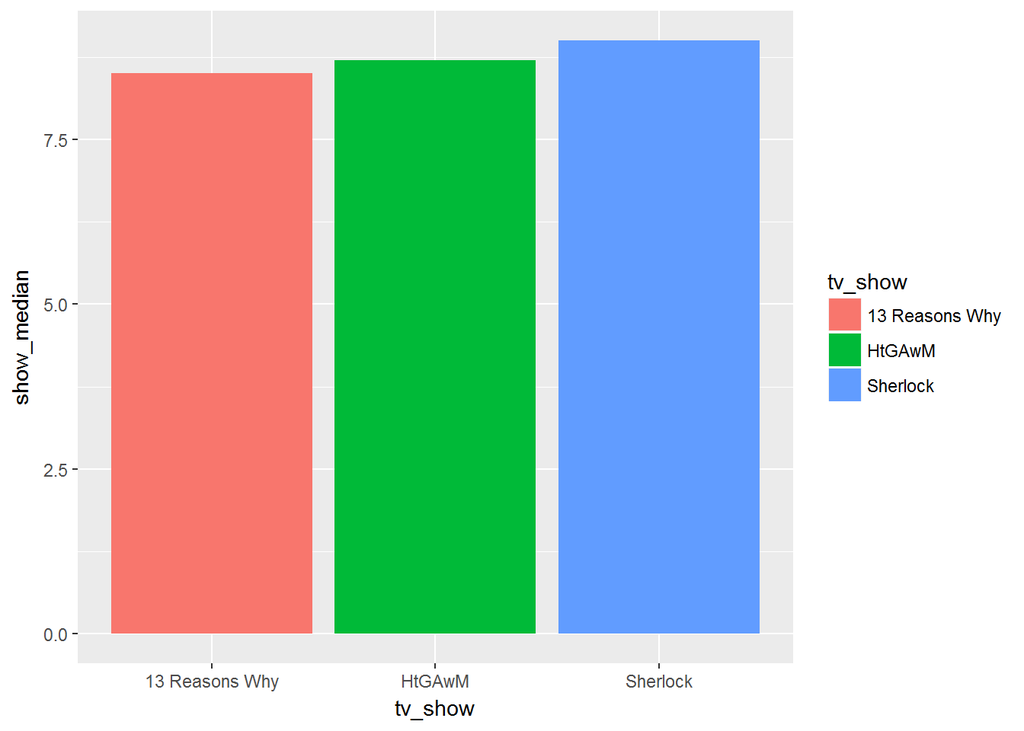

## b. Qual das séries que você escolheu tem episódios de qualidade mais irregular segundo o IMDB? A diferença é grande? Pequena?

Para ter uma melhor análise podemos observar como as avaliações são distribuidas em um gráfico BoxPlot.

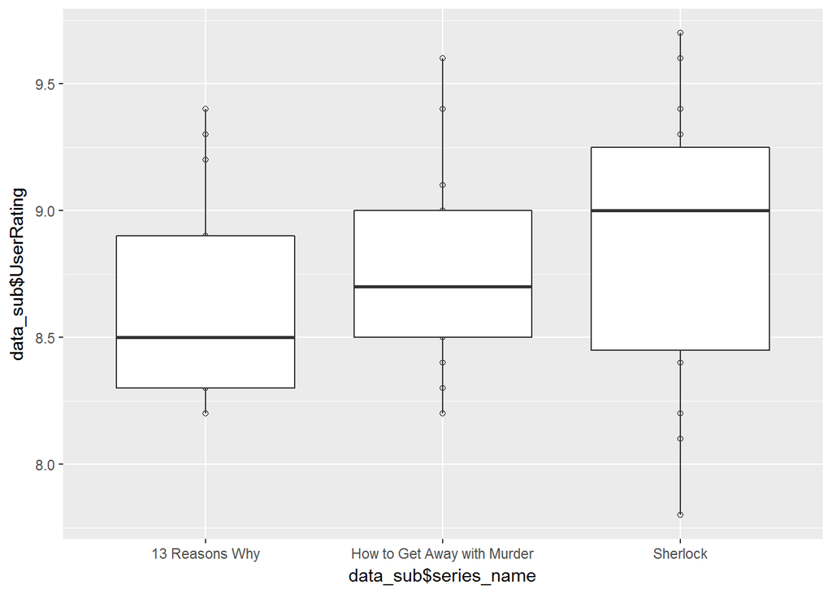

A partir desse gráfico podemos ver que a mediana do boxplot de **Sherlok** está acima das outras mas o bloxplot dele é o que apresenta maior espalhamento dos dados,já o de **How to Get Away with Murder** parece ser mais preciso e com notas mais constantes e proximas umas das outras, ou seja, **Sherlok** é o que possui notas mais irregulares dos 3 casos. Para afirmar que **Sherlok** é a série que mais possui episodios irregulares com mais certeza, podemos utilizar o desvio padrão, que é o quão disperso os dados estão em torno da média, de cada uma das séries e comparalos.

```r
sd(filter(data_sub, series_name == "Sherlock")$UserRating)
```

```
## [1] 0.5665266
```

```r
sd(filter(data_sub, series_name == "13 Reasons Why")$UserRating)
```

```
## [1] 0.4130872
```

```r
sd(filter(data_sub, series_name == "How to Get Away with Murder")$UserRating)
```

```
## [1] 0.3520216
```

Podemos ver que **Sherlok** possui a maior dipersão dentre as 3 séries selecionadas.

# Checkpoint 4

# As series ter um desempenho pior após uma com alto rating?

A primeira pergunta a se fazer é: *quando uma temporada é considerada com alto rating?* Utilizaremos a mediana da temporada e verificaremos se ela é alta, vamos definir que abaixo de 8.7 seja de baixo rating.

Então vamos agrupar as séries por temporada fazendo a mediana de cada temporada.

```r
tv_shows_resume <- group_by(data_all_shows,series_name,season) %>%
  summarize(eps = n(), median = median(UserRating, na.rm = T))

tv_shows_resume
```

```
## Source: local data frame [147 x 4]
## Groups: series_name [?]
##
## # A tibble: 147 x 4
##               series_name season   eps median
##                    <fctr>  <int> <int>  <dbl>
##  1         13 Reasons Why      1    13   8.50
##  2 Agents of S.H.I.E.L.D.      1    22   8.20
##  3 Agents of S.H.I.E.L.D.      2    22   8.60
##  4 Agents of S.H.I.E.L.D.      3    22   8.65
##  5 Agents of S.H.I.E.L.D.      4    21   8.80
##  6                  Arrow      1    23   8.50
##  7                  Arrow      2    23   8.90
##  8                  Arrow      3    23   8.70
##  9                  Arrow      4    23   8.20
## 10                  Arrow      5    21   8.50
## # ... with 137 more rows
```

Agora vamos ver a variação de uma temporada para outra para cada série.

```r
tv_shows_resume <- group_by(data_all_shows,series_name,season) %>%
  summarize(eps = n(), median = median(UserRating, na.rm = T)) %>%
  mutate(variation=(median - lag(median)), last_season = lag(median))

tv_shows_resume
```

```
## Source: local data frame [147 x 6]
## Groups: series_name [31]
##
## # A tibble: 147 x 6
##               series_name season   eps median variation last_season
##                    <fctr>  <int> <int>  <dbl>     <dbl>       <dbl>
##  1         13 Reasons Why      1    13   8.50        NA          NA
##  2 Agents of S.H.I.E.L.D.      1    22   8.20        NA          NA
##  3 Agents of S.H.I.E.L.D.      2    22   8.60      0.40        8.20
##  4 Agents of S.H.I.E.L.D.      3    22   8.65      0.05        8.60
##  5 Agents of S.H.I.E.L.D.      4    21   8.80      0.15        8.65
##  6                  Arrow      1    23   8.50        NA          NA
##  7                  Arrow      2    23   8.90      0.40        8.50
##  8                  Arrow      3    23   8.70     -0.20        8.90
##  9                  Arrow      4    23   8.20     -0.50        8.70
## 10                  Arrow      5    21   8.50      0.30        8.20
## # ... with 137 more rows
```

```r
tv_shows_resume <- group_by(data_all_shows,series_name,season) %>%
  summarize(eps = n(), median = median(UserRating, na.rm = T)) %>%
  mutate(variation=(median - lag(median)), last_season = lag(median)) %>%
  filter(variation < 0, last_season >= 8.7, median < 8.7)

tv_shows_resume
```

```
## Source: local data frame [10 x 6]
## Groups: series_name [8]
##
## # A tibble: 10 x 6
##                    series_name season   eps median variation last_season
##                         <fctr>  <int> <int>  <dbl>     <dbl>       <dbl>
##  1                       Arrow      4    23   8.20     -0.50        8.70
##  2                      Dexter      3    12   8.60     -0.25        8.85
##  3                      Dexter      6    12   8.40     -0.50        8.90
##  4                      Dexter      8    12   7.95     -0.90        8.85
##  5                       Flash      3    22   8.55     -0.35        8.90
##  6              House of Cards      3    13   8.50     -0.20        8.70
##  7 How to Get Away with Murder      3    15   8.60     -0.20        8.80
##  8            Once Upon a Time      4    24   8.50     -0.20        8.70
##  9                Prison Break      3    13   8.50     -0.20        8.70
## 10                    Sherlock      4     4   8.30     -0.75        9.05
```